# Gender Recognition by Voice with Tensorflow

```python
def plot(feature):
    fig,axes=plt.subplots(1,2)
    sns.boxplot(data=df,x=feature,ax=axes[0])
    sns.distplot(a=df[feature],ax=axes[1],color='#ff4125')
    fig.set_size_inches(15,5)

    lower,upper = calc_limits(feature)
    l=[df[feature] for i in df[feature] if i>lower and i<upper]
    print("Number of data points remaining if outliers removed : ",len(l))
```

```
Number of data points remaining if outliers removed :  3104
```

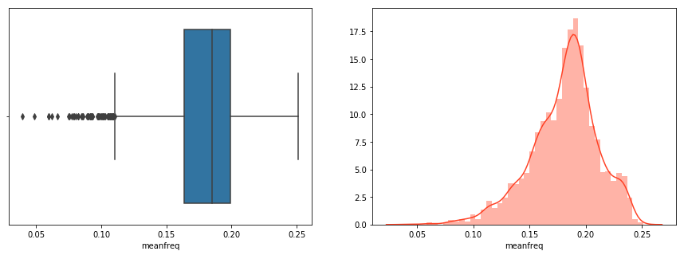

```python
plot('meanfreq')
```

```
Number of data points remaining if outliers removed :  3158
```

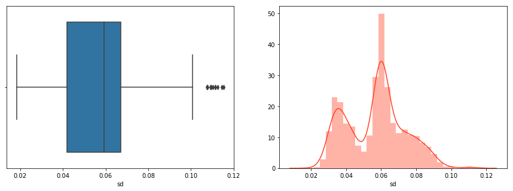

```python
plot('sd')
```

```
Number of data points remaining if outliers removed :  3059
```

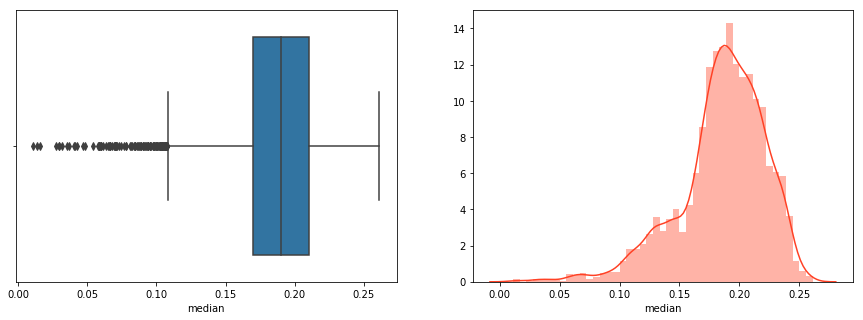

```python
plot('median')
```

```
Number of data points remaining if outliers removed :  3135
```

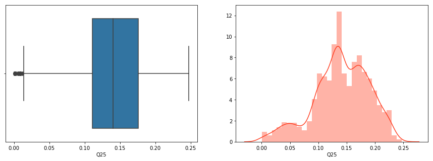

```python
plot('Q25')
```

```
Number of data points remaining if outliers removed :  3158
```

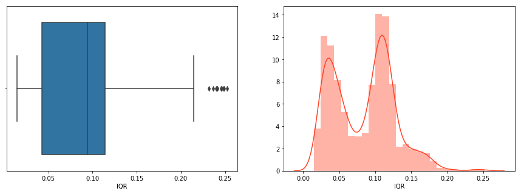

```python
plot('IQR')
```

```
Number of data points remaining if outliers removed :  2938
```

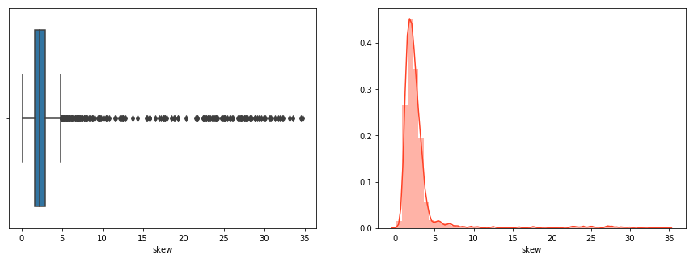

```python
plot('skew')
```

```
Number of data points remaining if outliers removed :  2836
```

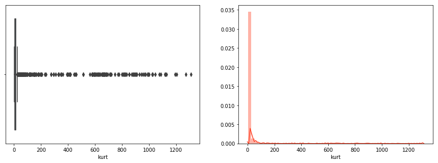

```python
plot('kurt')
```

```
Number of data points remaining if outliers removed :  3162
```

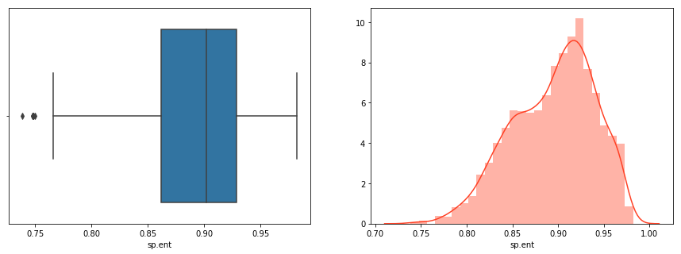

```python
plot('sp.ent')
```

```
Number of data points remaining if outliers removed :  3168
```

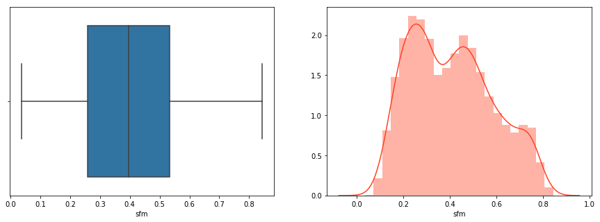

```python
plot('sfm')
```

```
Number of data points remaining if outliers removed :  3168
```

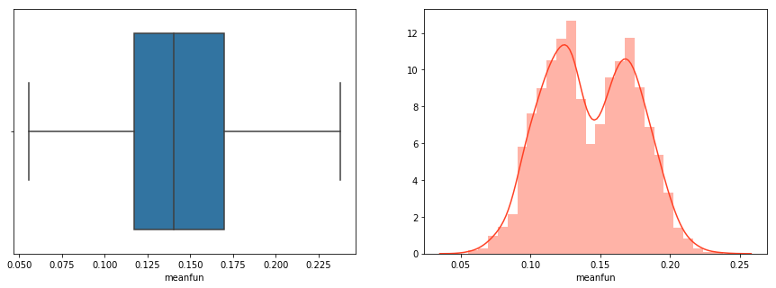

```python
plot('meanfun')
```

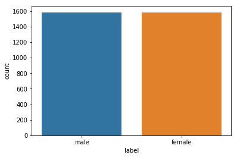

```python
sns.countplot(data=df,x='label')
```

## Data Correlation

use correlation heatmap to see the correlation between all features

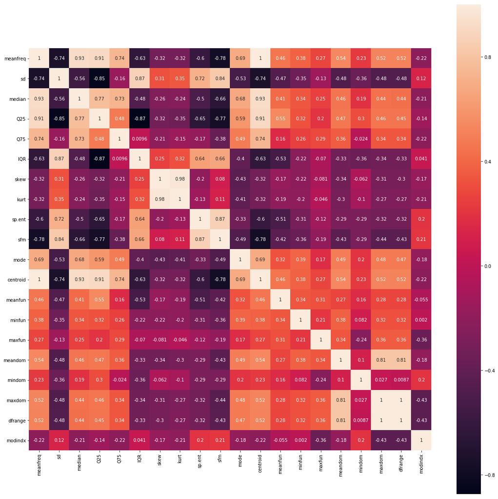

```python
fig = plt.subplots(figsize = (20,20))
sns.heatmap(df.corr(), square = True, annot = True)
plt.show()
```

## Transform Label into Numeric Form

- Female => 0
- Male => 1

```python
df.head()
```

|  | meanfreq | sd | median | Q25 | Q75 | IQR | skew | kurt | sp.ent | sfm | ... | centroid | meanfun | minfun | maxfun | meandom | mindom | maxdom | dfrange | modindx | label |
| --- | --- | --- | --- | --- | --- | --- | --- | --- | --- | --- | --- | --- | --- | --- | --- | --- | --- | --- | --- | --- | --- |
| 0 | 0.059781 | 0.064241 | 0.032027 | 0.015071 | 0.090193 | 0.075122 | 12.863462 | 274.402906 | 0.893369 | 0.491918 | ... | 0.059781 | 0.084279 | 0.015702 | 0.275862 | 0.007812 | 0.007812 | 0.007812 | 0.000000 | 0.000000 | male |
| 1 | 0.066009 | 0.067310 | 0.040229 | 0.019414 | 0.092666 | 0.073252 | 22.423285 | 634.613855 | 0.892193 | 0.513724 | ... | 0.066009 | 0.107937 | 0.015826 | 0.250000 | 0.009014 | 0.007812 | 0.054688 | 0.046875 | 0.052632 | male |
| 2 | 0.077316 | 0.083829 | 0.036718 | 0.008701 | 0.131908 | 0.123207 | 30.757155 | 1024.927705 | 0.846389 | 0.478905 | ... | 0.077316 | 0.098706 | 0.015656 | 0.271186 | 0.007990 | 0.007812 | 0.015625 | 0.007812 | 0.046512 | male |
| 3 | 0.151228 | 0.072111 | 0.158011 | 0.096582 | 0.207955 | 0.111374 | 1.232831 | 4.177296 | 0.963322 | 0.727232 | ... | 0.151228 | 0.088965 | 0.017798 | 0.250000 | 0.201497 | 0.007812 | 0.562500 | 0.554688 | 0.247119 | male |
| 4 | 0.135120 | 0.079146 | 0.124656 | 0.078720 | 0.206045 | 0.127325 | 1.101174 | 4.333713 | 0.971955 | 0.783568 | ... | 0.135120 | 0.106398 | 0.016931 | 0.266667 | 0.712812 | 0.007812 | 5.484375 | 5.476562 | 0.208274 | male |

5 rows × 21 columns

```python
from sklearn import preprocessing
le = preprocessing.LabelEncoder()
df['label'] = le.fit_transform(df['label'])
```

### Splitting data into x and y

```python
x = df.drop("label", 1).values
```

```python
y_list = []
def get_zeros(row):
    zeros = np.zeros(2)
    zeros[row] = 1
    y_list.append(zeros)
    return zeros

df['label'] = df['label'].apply(lambda x: get_zeros(x))
y = np.asarray(y_list)
```

```python
df.head()
```

|  | meanfreq | sd | median | Q25 | Q75 | IQR | skew | kurt | sp.ent | sfm | ... | centroid | meanfun | minfun | maxfun | meandom | mindom | maxdom | dfrange | modindx | label |
| --- | --- | --- | --- | --- | --- | --- | --- | --- | --- | --- | --- | --- | --- | --- | --- | --- | --- | --- | --- | --- | --- |
| 0 | 0.059781 | 0.064241 | 0.032027 | 0.015071 | 0.090193 | 0.075122 | 12.863462 | 274.402906 | 0.893369 | 0.491918 | ... | 0.059781 | 0.084279 | 0.015702 | 0.275862 | 0.007812 | 0.007812 | 0.007812 | 0.000000 | 0.000000 | [0.0, 1.0] |
| 1 | 0.066009 | 0.067310 | 0.040229 | 0.019414 | 0.092666 | 0.073252 | 22.423285 | 634.613855 | 0.892193 | 0.513724 | ... | 0.066009 | 0.107937 | 0.015826 | 0.250000 | 0.009014 | 0.007812 | 0.054688 | 0.046875 | 0.052632 | [0.0, 1.0] |
| 2 | 0.077316 | 0.083829 | 0.036718 | 0.008701 | 0.131908 | 0.123207 | 30.757155 | 1024.927705 | 0.846389 | 0.478905 | ... | 0.077316 | 0.098706 | 0.015656 | 0.271186 | 0.007990 | 0.007812 | 0.015625 | 0.007812 | 0.046512 | [0.0, 1.0] |
| 3 | 0.151228 | 0.072111 | 0.158011 | 0.096582 | 0.207955 | 0.111374 | 1.232831 | 4.177296 | 0.963322 | 0.727232 | ... | 0.151228 | 0.088965 | 0.017798 | 0.250000 | 0.201497 | 0.007812 | 0.562500 | 0.554688 | 0.247119 | [0.0, 1.0] |
| 4 | 0.135120 | 0.079146 | 0.124656 | 0.078720 | 0.206045 | 0.127325 | 1.101174 | 4.333713 | 0.971955 | 0.783568 | ... | 0.135120 | 0.106398 | 0.016931 | 0.266667 | 0.712812 | 0.007812 | 5.484375 | 5.476562 | 0.208274 | [0.0, 1.0] |

5 rows × 21 columns

### Splitting training and testing datasets

```python
from sklearn.model_selection import train_test_split

x_train, x_test, y_train, y_test = train_test_split(x, y, test_size=0.2, random_state=0)
```

### Scaling the data set

```python
# Feature Scaling
from sklearn.preprocessing import StandardScaler

sc = StandardScaler()
x_train = sc.fit_transform(x_train)
x_test = sc.transform(x_test)
```

### Get batch function

```python
import random

# A function to get a batch of data
def getbatch(xval, yval, batchsize=300):
    arraylength = xval.shape[0]
    count = 0
    while count < arraylength/batchsize:
        randstart = random.randint(0, arraylength-batchsize-1)
        count += 1
        yield xval[randstart:randstart+batchsize], yval[randstart:randstart+batchsize]

# Test
#for i in getbatch(x_train, y_train):
#    print(i)
```

## Modeling

1. Multilayer Perceptron
2. RNN

```python
ninput = 20
noutput = 2
nepochs = 50
batch_size = 5
```

#### Defining X and Y as placeholders

```python
X = tf.placeholder(tf.float32, [None, ninput])
Y = tf.placeholder(tf.float32, [None, noutput])
```

### 1. Multilayer Perceptron

#### Hyperparameters

```python
#learningrate = 0.001
learningrates = [0.001, 0.01, 0.1]

nhidden1 = 256
nhidden2 = 256
```

#### Initializing Weights and Biases

```python
weights = \
{
    'h1': tf.Variable(tf.random_normal([ninput, nhidden1])),
    'h2': tf.Variable(tf.random_normal([nhidden1, nhidden2])),
    'out': tf.Variable(tf.random_normal([nhidden2, noutput]))
}

biases = \
{
    'b1': tf.Variable(tf.random_normal([nhidden1])),
    'b2': tf.Variable(tf.random_normal([nhidden2])),
    'out': tf.Variable(tf.random_normal([noutput]))
}
```

#### Defining model using sigmoid activation function

```python
def multiperceptron(x):
    l1 = tf.nn.sigmoid(tf.add(tf.matmul(x, weights['h1']), biases['b1']))
    l2 = tf.nn.sigmoid(tf.add(tf.matmul(l1, weights['h2']), biases['b2']))
    outl = tf.nn.sigmoid(tf.add(tf.matmul(l2, weights['out']), biases['out']))
    return outl

model = multiperceptron(X)
```

#### Define cost, optimizer and accuracy & Run the session

```python
for lr in learningrates:
    print("----------------------")
    print("Learning Rate: {}".format(lr))
    # Define cost, optimizer and accuracy
    loss = tf.reduce_mean(tf.nn.softmax_cross_entropy_with_logits(logits = model, labels=Y))
    optimizer = tf.train.AdamOptimizer(learning_rate=lr)
    train_min = optimizer.minimize(loss)

    correct_prediction = tf.equal(tf.argmax(model, 1), tf.argmax(Y, 1))
    accuracy = tf.reduce_mean(tf.cast(correct_prediction, tf.float32))

    init = tf.global_variables_initializer()

    with tf.Session() as sess:
        sess.run(init)

        for epoch in range(nepochs):
            for (x, y) in getbatch(x_train, y_train, batch_size):
                # Use training data for optimization
                sess.run(train_min, feed_dict={X:x, Y:y})

            # Validate after every epoch
            #losscalc, accuracycalc = sess.run([loss, accuracy], feed_dict={X:x_train, Y:y_train})
            #print("Epoch: %d, Loss: %0.4f, Accuracy: %0.4f"%(epoch+1, losscalc, accuracycalc))

        # When the training is complete and you are happy with the result
        accuracycalc = sess.run(accuracy, feed_dict={X: x_test, Y: y_test})
        print("Testing accuracy: %0.4f"%(accuracycalc))
```

```
----------------------
Learning Rate: 0.001
Testing accuracy: 0.9779
----------------------
Learning Rate: 0.01
Testing accuracy: 0.9558
----------------------
Learning Rate: 0.1
Testing accuracy: 0.4748
```

### 2. RNN

#### Initializing Weights and Biases

```python
weights = {
    'out': tf.Variable(tf.random_normal([nhidden1, noutput]))
}
biases = {
    'out': tf.Variable(tf.random_normal([noutput]))
}
```

#### Defining RNN function

```python
def RNN(x, weights, biases):
    x = tf.reshape(x, [-1, ninput])
    x = tf.split(x,ninput,1)
    rnn_cell = tf.contrib.rnn.BasicLSTMCell(nhidden1)
    outputs, states = tf.contrib.rnn.static_rnn(rnn_cell, x, dtype=tf.float32)
    return tf.matmul(outputs[-1], weights['out']) + biases['out']

pred = RNN(X, weights, biases)
```

#### Define cost, optimizer and accuracy & Run the session

```python
for lr in learningrates:
    print("----------------------")
    print("Learning Rate: {}".format(lr))
    # Define cost, optimizer and accuracy
    cost = tf.reduce_mean(tf.nn.softmax_cross_entropy_with_logits(logits=pred, labels=Y))
    optimizer = tf.train.RMSPropOptimizer(learning_rate=lr).minimize(cost)

    correct_pred = tf.equal(tf.argmax(pred,1), tf.argmax(Y,1))
    accuracy = tf.reduce_mean(tf.cast(correct_pred, tf.float32))

    init = tf.global_variables_initializer()

    with tf.Session() as sess:
        sess.run(init)

        for epoch in range(nepochs):
            for (x, y) in getbatch(x_train, y_train, batch_size):
                # Use training data for optimization
                sess.run(optimizer, feed_dict={X:x, Y:y})

            # Validate after every epoch
            #losscalc, accuracycalc = sess.run([cost, accuracy], feed_dict={X:x_train, Y:y_train})
            #print("Epoch: %d, Loss: %0.4f, Accuracy: %0.4f"%(epoch+1, losscalc, accuracycalc))

        # When the training is complete and you are happy with the result
        accuracycalc = sess.run(accuracy, feed_dict={X: x_test, Y: y_test})
        # print("Learning Rate: {}".format(lr))
        print("Testing accuracy: %0.4f"%(accuracycalc))
```

```
----------------------
Learning Rate: 0.001
Testing accuracy: 0.9732
----------------------
Learning Rate: 0.01
Testing accuracy: 0.9527
----------------------
Learning Rate: 0.1
Testing accuracy: 0.5899
```

## Conclusion

- num of input = 20
- num of output = 2
- num of epochs = 50
- Multilayer Perceptron:
  - node of hidden1 = 256
  - node of hidden2 = 256
  - sigmoid
  - Accuracy:
    - learningrate = 0.001 => 97%
    - learningrate = 0.01 => 95%
    - learningrate = 0.1 => 47%
- RNN:
  - node of hidden = 256
  - BasicLSTMCell
  - Accuracy:
    - learningrate = 0.001 => 97%
    - learningrate = 0.01 => 95%
    - learningrate = 0.1 => 58%
  - time consuming